# aghq: Adaptive Gauss-Hermite Quadrature for Bayesian inference

```r
library(aghq)
```

This vignette describes the `aghq` package for Bayesian inference using Adaptive Gauss Hermite Quadrature as described by Bilodeau, Stringer, and Tang (2020). It is taken almost verbatim from Section 2 (Basic Use) of Stringer (2020). It shows how to use the basic functions of the package to implement a very simple example of Bayesian inference using adaptive quadrature. For six challenging and illuminating examples, consult Stringer (2020).

# A simple example

The following conjugate model is used by Bilodeau, Stringer, and Tang (2020):
$$\begin{equation}\begin{aligned}
Y_i | \lambda &\overset{ind}{\sim} \text{Poisson}(\lambda), i\in[n], \\
\lambda &\sim \text{Exponential}(1), \lambda > 0, \\
\implies \lambda | Y &\sim \text{Gamma}\left(1 + \sum_{i=1}^{n}y_{i},n+1\right), \\
\pi(\lambda,Y) &= \frac{\lambda^{\sum_{i=1}^{n}y_{i}}e^{-n\lambda}}{\prod_{i=1}^{n}y_{i}!}\times e^{-\lambda}, \\
\pi(Y) &= \frac{\Gamma\left(1 + \sum_{i=1}^{n}y_{i}\right)}{(n+1)^{\left(1 + \sum_{i=1}^{n}y_{i}\right)}\prod_{i=1}^{n}y_{i}!}
\end{aligned}\end{equation}$$
We apply a transformation:
$$\begin{equation}\begin{aligned}
\eta &= \log\lambda, \\
\implies \log\pi(\eta,Y) &= \eta\sum_{i=1}^{n}y_{i} - (n+1)e^{\eta} - \sum_{i=1}^{n}\log(y_{i}!) + \eta, \\
\end{aligned}\end{equation}$$
which, because the jacobian $|d\lambda/d\eta|$ is included, does not change the value of $\pi(Y)$.

To approximate $\pi(Y)$ and then make Bayesian inferences based on $\pi(\lambda|Y)$, first install and load the package:

```r
# Stable version:
# install.packages("aghq")
# Or devel version:
# devtools::install_github("awstringer1/aghq")
```

We will simulate some data from the model:

```r
set.seed(84343124)
y <- rpois(10,5) # True lambda = 5, n = 10
```

The main function is the `aghq::aghq` function. The user supplies a list containing the log-posterior and its first two derivatives:

```r
# Define the log posterior, log(pi(eta,y)) here
logpietay <- function(eta,y) {
  sum(y) * eta - (length(y) + 1) * exp(eta) - sum(lgamma(y+1)) + eta
}
# The objective function has to take a single argument, eta, so pass
# in the data:
objfunc <- function(x) logpietay(x,y)
# Simple numerical derivatives suffice here:
objfuncgrad <- function(x) numDeriv::grad(objfunc,x)
objfunchess <- function(x) numDeriv::hessian(objfunc,x)
# Now create the list to pass to aghq()
funlist <- list(
  fn = objfunc,
  gr = objfuncgrad,
  he = objfunchess
)
```

Now perform the quadrature. The only other required input is the number of quadrature points, $k$, and a starting value for the optimization:

```r
# AGHQ with k = 3
# Use eta = 0 as a starting value
thequadrature <- aghq::aghq(ff = funlist,k = 3,startingvalue = 0)
```

The object `thequadrature` has class `aghq`, with `summary` and `plot` methods:

```r
summary(thequadrature)
```

```
#> AGHQ on a 1 dimensional posterior with  3 quadrature points
#>
#> The posterior mode is: 1.493925
#>
#> The log of the normalizing constant/marginal likelihood is: -23.32123
#>
#> The posterior Hessian at the mode is:
#>      [,1]
#> [1,]   49
#>
#> The covariance matrix used for the quadrature is...
#>            [,1]
#> [1,] 0.02040816
#>
#> ...and its Cholesky is:
#>           [,1]
#> [1,] 0.1428571
#>
#> Here are some moments and quantiles for theta:
#>
#>            mean   median     mode        sd     2.5%    97.5%
#> theta1 1.483742 1.482532 1.493925 0.1424943 1.204135 1.762909
```

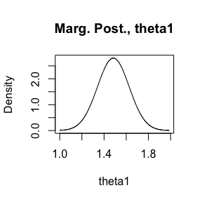

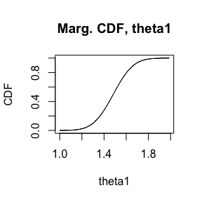

```r
plot(thequadrature)
```

We can observe the structure of the object and compare the results to the truth for this simple example:

```r
# The normalized posterior:
thequadrature$normalized_posterior$nodesandweights
```

```
#>     theta1   weights   logpost logpost_normalized
#> 1 1.246489 0.2674745 -23.67784         -0.3566038
#> 2 1.493925 0.2387265 -22.29426          1.0269677
#> 3 1.741361 0.2674745 -23.92603         -0.6047982
```

```r
# The log normalization constant:
options(digits = 6)
thequadrature$normalized_posterior$lognormconst
```

```
#> [1] -23.3212
```

```r
# Compare to the truth:
lgamma(1 + sum(y)) - (1 + sum(y)) * log(length(y) + 1) - sum(lgamma(y+1))
```

```
#> [1] -23.3195
```

```r
# Quite accurate with only n = 10 and k = 3; this example is very simple.
# The mode found by the optimization:
thequadrature$optresults$mode
```

```
#> [1] 1.49393
```

```r
# The true mode:
log((sum(y) + 1)/(length(y) + 1))
```

```
#> [1] 1.49393
```

```r
options(digits = 3)
```

Of course, in practical problems, the true mode and normalizing constant won’t be known.

The package provides further routines for computing moments, quantiles, and distributions/densities. These are especially useful when working with transformations and we are in the example, since interest here is in the original parameter $\lambda = e^{\eta}$. The main functions are:

- `compute_pdf_and_cdf`: compute the density and cumulative distribution function for a marginal posterior distribution of a variable and (optionally) a smooth monotone transformation of that variable,
- `compute_moment`: compute the posterior moment of any function,
- `compute_quantiles`: compute posterior quantiles for a marginal posterior distribution.

We will consider several examples. To compute the approximate marginal posterior for $\lambda$, $\widetilde{\pi}(\lambda|Y)$, first compute the marginal posterior for $\eta$ and then transform:
$$\begin{equation}
\widetilde{\pi}(\lambda|Y) = \widetilde{\pi}(\eta|Y)|\frac{d\eta}{d\lambda}|
\end{equation}$$

The `aghq::compute_pdf_and_cdf` function has an option, `transformation`, which allows the user to specify a parameter transformation that they would like the marginal density of. The user specifies functions `fromtheta` and `totheta` which convert from and to the transformed scale (on which quadrature was done), and the function returns the marginal density on both scales, making use of a numerically differentiated jacobian. This is all done as follows:

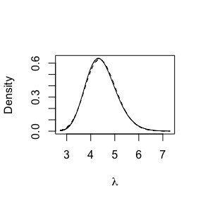

Approximate (—) and true (- - -) posterior for $\lambda$

```r
# Compute the pdf for eta
pdfwithlambda <- compute_pdf_and_cdf(
  thequadrature$marginals[[1]],
  transformation = list(
    totheta = function(x) log(x),
    fromtheta = function(x) exp(x)
  )
)
# Plot along with the true posterior
# lambdapostplot <- pdfwithlambda %>%
#   ggplot(aes(x = transparam,y = pdf_transparam)) +
#   theme_classic() +
#   geom_line() +
#   stat_function(fun = dgamma,
#                 args = list(shape = 1+sum(y),rate = 1 + length(y)),
#                 linetype = 'dashed') +
#   labs(x = expression(lambda),y = "Density")

with(pdfwithlambda,plot(transparam,pdf_transparam,type='l',xlab = expression(lambda),ylab = "Density"))
with(pdfwithlambda,lines(transparam,dgamma(transparam,shape = 1+sum(y),rate = 1+length(y)),lty='dashed'))
```

```r
options(digits = 6)
# Check if the posterior integrates to 1, by computing the "moment" of "1":
compute_moment(thequadrature$normalized_posterior,
               ff = function(x) 1)
```

```
#> [1] 1
```

```r
# Posterior mean for eta:
compute_moment(thequadrature$normalized_posterior,
               ff = function(x) x)
```

```
#> [1] 1.48374
```

```r
# Posterior mean for lambda = exp(eta)
compute_moment(thequadrature$normalized_posterior,
               ff = function(x) exp(x))
```

```
#> [1] 4.45441
```

```r
# Compare to the truth:
(sum(y) + 1)/(length(y) + 1)
```

```
#> [1] 4.45455
```

```r
options(digits = 3)
```

```r
# Get the quantiles for eta:
etaquants <- compute_quantiles(
  thequadrature$marginals[[1]],
  q = c(.01,.25,.50,.75,.99)
)
# The quantiles for lambda = exp(eta) are obtained directly:
exp(etaquants)
```

```
#>   1%  25%  50%  75%  99%
#> 3.17 4.00 4.40 4.85 6.15
```

```r
# and compared with the truth:
qgamma(c(.01,.25,.50,.75,.99),shape = 1+sum(y),rate = 1+length(y))
```

```
#> [1] 3.11 4.01 4.42 4.87 6.07
```

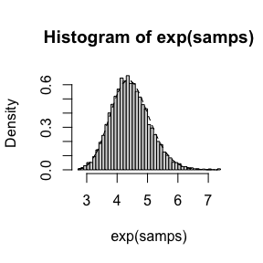

```r
# Can be used to get approximate posterior samples:
M <- 1e04 # 10,000 samples
samps <- compute_quantiles(thequadrature$marginals[[1]],runif(M))
hist(exp(samps),breaks = 50,freq=FALSE)
with(pdfwithlambda,lines(transparam,dgamma(transparam,shape = 1+sum(y),rate = 1+length(y)),lty='dashed'))
```

For more details, see Bilodeau, Stringer, and Tang (2020) and Stringer (2020).

# References

Bilodeau, Blair, Alex Stringer, and Yanbo Tang. 2020. “Higher Order Accurate Approximate Bayesian Inference Using Adaptive Quadrature.” *In Preparation*.

Stringer, Alex. 2020. “Implementing Adaptive Quadrature for Bayesian Inference: The Aghq Package.” *In Preparation*.